# Lab1

Eamon Espey

2022-11-06

```r
# load necessary libraries
library(tmap)
library(sf)
library(rgdal)
```

```r
library(raster)
library(plotly)
setwd('C:/Users/eespey/Documents/school/F22/EAS648/Lab1')

# read in shapefile for US state outlines
states = read_sf('cb_2018_us_state_500k/cb_2018_us_state_500k.shp')

# read in bathymetry rasters for high and low resolution (bathy and bathy2, respectively)
lake = 'salton_sea'
bathy = raster(sprintf('bathy/GLOBathy/%s.tif', lake))
bathy2 = raster(sprintf('bathy/%s_Bilinear.nc', lake))
bathy2[bathy2==0]=NA

# create color palette and zlim
cols = colorRampPalette(c('lightblue','blue'))
lim = max(c(max(na.omit(as.vector(bathy))), max(na.omit(as.vector(bathy2)))))
```

To start with, let’s get some perspective on where we are focusing this analysis. Salton Sea is a saline lake, which, as shown in the map below, is located in southern California.

```r
plot.new()
```

```r
map_calif = tm_shape(states[states$STUSPS == 'CA',])+tm_polygons()+tm_shape(bathy)+tm_raster(col = 'black')+tm_shape(bathy)+tm_raster(palette = 'Blues', legend.show=F)
map_salt = tm_shape(bathy)+tm_raster(title = 'Lake depth (m)', palette = 'Blues')+tm_compass(position = c('right', 'bottom'))+tm_scale_bar(position = c('right', 'bottom'))+
tm_layout("Salton Sea",
          legend.position = c('right', 'top'))
map_salt
```

```
## stars object downsampled to 1084 by 922 cells. See tm_shape manual (argument raster.downsample)
```

```
## stars object downsampled to 1084 by 922 cells. See tm_shape manual (argument raster.downsample)
## stars object downsampled to 1084 by 922 cells. See tm_shape manual (argument raster.downsample)
```

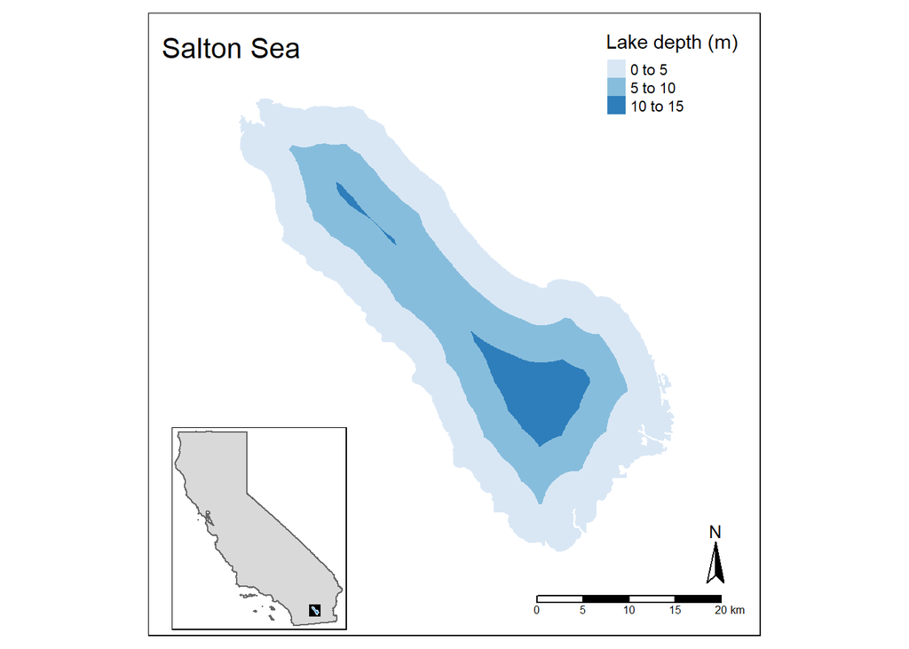

```r
print(map_calif, vp = grid::viewport(0.285, 0.185, width = 0.2, height = 0.45))
```

Now let’s visualize the bathymetry (underwater topography) utilizing the full resolution with a continuous color scheme. This data came from Khazaei et al. 2022.

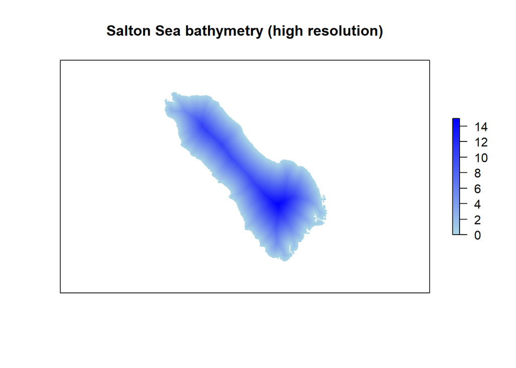

```r
plot(bathy, col = cols(length(bathy)), zlim = c(0, lim), xaxt = "n", yaxt = "n", main = 'Salton Sea bathymetry (high resolution)')
```

Looks great! But unfortunately, this is much too high of resolution for use in numerical weather prediction. What does the bathymetry look like if it’s resampled to the resolution of NOAA’s High Resolution Rapid Refresh (3km grid in lambert conformal conic projection)?

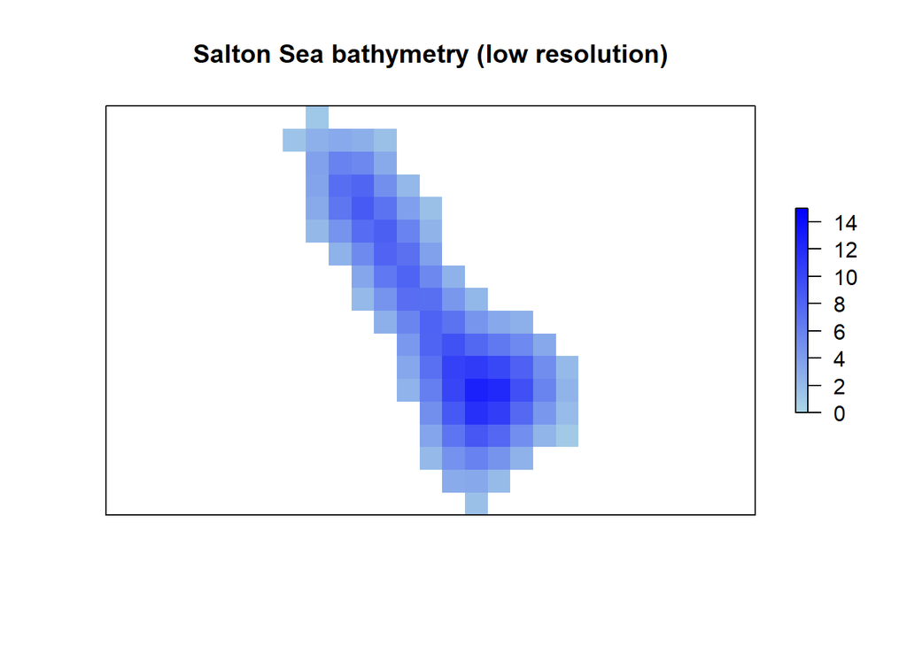

```r
plot(bathy2, col = cols(length(bathy)), zlim = c(0, lim), xaxt = "n", yaxt = "n", main = 'Salton Sea bathymetry (low resolution)')
```

It looks like the spatial pattern is maintained fairly well through this resampling, but what story does the distribution of lake depth values tell us? This can be best visualized with a histogram. First, let’s look at the distribution of lake depths in the high resolution bathymetry.

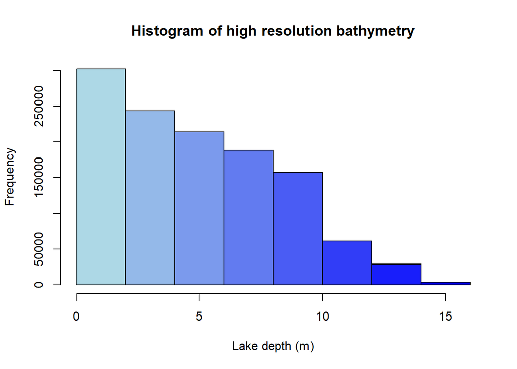

```r
hist(na.omit(as.vector(bathy)), breaks = seq(0,16,2), col = cols(8), main='Histogram of high resolution bathymetry', xlab='Lake depth (m)')
```

The high resolution bathymetry has negative relationship between depth and frequency of lake depth values. What about in the low resolution bathymetry?

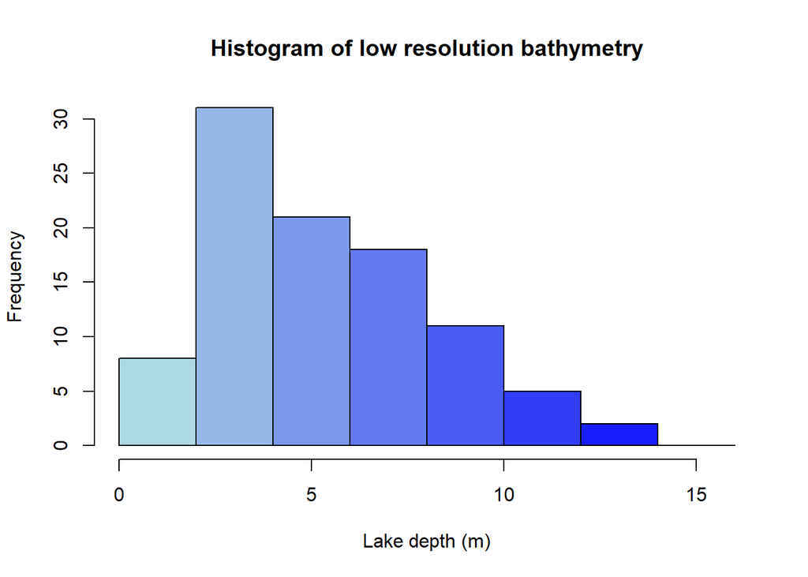

```r
hist(na.omit(as.vector(bathy2)), breaks = seq(0,16,2), col = cols(8), main='Histogram of low resolution bathymetry', xlab='Lake depth (m)')
```

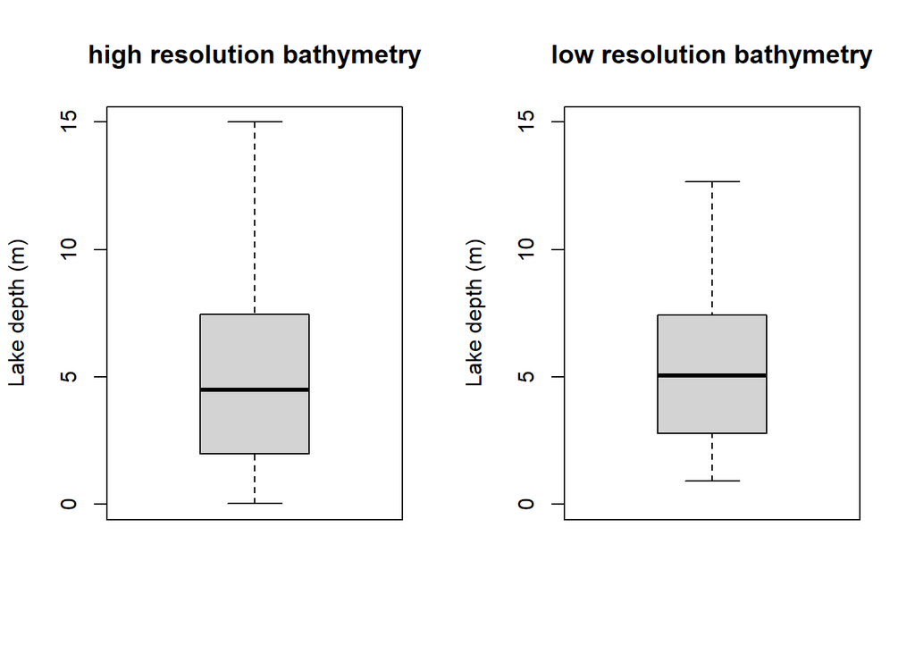

```r
par(mfrow = c(1,2))
boxplot(bathy, ylim = c(0,lim), main = 'high resolution bathymetry', ylab = 'Lake depth (m)')
boxplot(bathy2, ylim = c(0,lim), main = 'low resolution bathymetry', ylab = 'Lake depth (m)')
```

The boxplots look pretty similar, but it looks like the boxplot for the high resolution bathymetry has a bit more “spread” or variance to it. Are these observations statistically significant? Let’s look at the student’s t-test and the F-test to analyze mean and variance respectively.

```r
t.test(bathy, bathy2)
```

```
##
##  Welch Two Sample t-test
##
## data:  bathy and bathy2
## t = -1.5177, df = 95.022, p-value = 0.1324
## alternative hypothesis: true difference in means is not equal to 0
## 95 percent confidence interval:
##  -1.0153148  0.1355283
## sample estimates:
## mean of x mean of y
##  4.913976  5.353869
```

```r
var.test(bathy,bathy2)
```

```
##
##  F test to compare two variances
##
## data:  bathy and bathy2
## F = 1.423, num df = 1200184, denom df = 95, p-value = 0.02468
## alternative hypothesis: true ratio of variances is not equal to 1
## 95 percent confidence interval:
##  1.047376 1.855218
## sample estimates:
## ratio of variances
##           1.422966
```

While we cannot reject the null hypothesis that the mean is the same in each bathymetry dataset, we can say with at least 97.5% confidence that the two bathymertry datasets have different variances.